# Lecture 11: Subsetting Data

Topics you should know up to this point:

- *Data Types:* int, float, str, lists, arrays,

booleans, pandas dataframes

- *Numpy:* mathematical functions

and random numbers

- If/else statements and *loops*

If there are any of these topics you need help  
understanding, don't be afraid to come to office hours!

This lecture:

- pandas dataframes
- subsetting data

## I. Import Libraries and Read Files

```python
# the "pandas" library is for manipualting datasets
# the "matplotlib.pyplot" library is for creating graphs
import pandas as pd
import matplotlib.pyplot as plt
```

How should I load in the .csv file inside the data_raw folder?

```python
# Read the car features dataset

carfeatures = pd.read_csv("data_raw/subfolder1/annoying_subfolder/features.csv")
```

```python
type(carfeatures)
```

```
pandas.core.frame.DataFrame
```

## II. Basic data display

- Go to the Jupyter Variables tab at the top of the notebook. Then click on icon to the left of "carfeatures"
- OR type `print(carfeatures)`
- OR simply type `carfeatures` as the last line of a cell

```python
print(carfeatures)
```

```
      mpg  cylinders  displacement horsepower  weight  acceleration vehicle_id
0    18.0          8           307        130    3504          12.0  C-1689780
1    15.0          8           350        165    3693          11.5  B-1689791
2    18.0          8           318        150    3436          11.0  P-1689802
3    16.0          8           304        150    3433          12.0  A-1689813
4    17.0          8           302        140    3449          10.5  F-1689824
..    ...        ...           ...        ...     ...           ...        ...
393  27.0          4           140         86    2790          15.6  F-1694103
394  44.0          4            97         52    2130          24.6  V-1694114
395  32.0          4           135         84    2295          11.6  D-1694125
396  28.0          4           120         79    2625          18.6  F-1694136
397  31.0          4           119         82    2720          19.4  C-1694147

[398 rows x 7 columns]
```

```python
carfeatures
```

|  | mpg | cylinders | displacement | horsepower | weight | acceleration | vehicle_id |
| --- | --- | --- | --- | --- | --- | --- | --- |
| 0 | 18.0 | 8 | 307 | 130 | 3504 | 12.0 | C-1689780 |
| 1 | 15.0 | 8 | 350 | 165 | 3693 | 11.5 | B-1689791 |
| 2 | 18.0 | 8 | 318 | 150 | 3436 | 11.0 | P-1689802 |
| 3 | 16.0 | 8 | 304 | 150 | 3433 | 12.0 | A-1689813 |
| 4 | 17.0 | 8 | 302 | 140 | 3449 | 10.5 | F-1689824 |
| ... | ... | ... | ... | ... | ... | ... | ... |
| 393 | 27.0 | 4 | 140 | 86 | 2790 | 15.6 | F-1694103 |
| 394 | 44.0 | 4 | 97 | 52 | 2130 | 24.6 | V-1694114 |
| 395 | 32.0 | 4 | 135 | 84 | 2295 | 11.6 | D-1694125 |
| 396 | 28.0 | 4 | 120 | 79 | 2625 | 18.6 | F-1694136 |
| 397 | 31.0 | 4 | 119 | 82 | 2720 | 19.4 | C-1694147 |

398 rows × 7 columns

## III. Extract column/variable names

In Homework #2, you manually created a list of column names. Pandas can do that for you

```python
car_colnames = carfeatures.columns.values
print(car_colnames)

# Is this a list? A Numpy array? Are you checking what objects are, or just coding
# with reckless abandon?

print(type(car_colnames))
print(type(car_colnames[0]))
```

```
['mpg' 'cylinders' 'displacement' 'horsepower' 'weight' 'acceleration'
 'vehicle_id']
<class 'numpy.ndarray'>
<class 'str'>
```

```python
# Just like HW #2, we can use car_colnames to grab columns from the dataset

# manually..
mpg = carfeatures["mpg"]

# using car_colnames
mpg_alt = carfeatures[car_colnames[0]]
print(mpg)
print(mpg_alt)
```

```
0      18.0
1      15.0
2      18.0
3      16.0
4      17.0
       ...
393    27.0
394    44.0
395    32.0
396    28.0
397    31.0
Name: mpg, Length: 398, dtype: float64
0      18.0
1      15.0
2      18.0
3      16.0
4      17.0
       ...
393    27.0
394    44.0
395    32.0
396    28.0
397    31.0
Name: mpg, Length: 398, dtype: float64
```

```python
# Did you check the TYPE ?!
print(type(mpg))
```

```
<class 'pandas.core.series.Series'>
```

Grab multiple variables

```python
list_subsetcols = ["weight","mpg"]
subcols_carfeatures = carfeatures[list_subsetcols]

print(type(subcols_carfeatures))
print(subcols_carfeatures)
```

```
<class 'pandas.core.frame.DataFrame'>
     weight   mpg
0      3504  18.0
1      3693  15.0
2      3436  18.0
3      3433  16.0
4      3449  17.0
..      ...   ...
393    2790  27.0
394    2130  44.0
395    2295  32.0
396    2625  28.0
397    2720  31.0

[398 rows x 2 columns]
```

```python
# list_subsetcols = ["weight","mpg"] # created a variable list_subsetcols...
# subcols_carfeatures = carfeatures[list_subsetcols] # ...just to place it within the brackets

# skip the intermediate variable
subcols_carfeatures = carfeatures[["weight", "mpg"]]
print(subcols_carfeatures)
```

```
     weight   mpg
0      3504  18.0
1      3693  15.0
2      3436  18.0
3      3433  16.0
4      3449  17.0
..      ...   ...
393    2790  27.0
394    2130  44.0
395    2295  32.0
396    2625  28.0
397    2720  31.0

[398 rows x 2 columns]
```

```python
print(car_colnames[4])
print(car_colnames[0])
```

```
weight
mpg
```

```python
# Use car_colnames plus the indices 4, 0
list_subsetcols = [car_colnames[4], car_colnames[0]]
subcols_carfeatures = carfeatures[list_subsetcols]
print(subcols_carfeatures)
```

```
     weight   mpg
0      3504  18.0
1      3693  15.0
2      3436  18.0
3      3433  16.0
4      3449  17.0
..      ...   ...
393    2790  27.0
394    2130  44.0
395    2295  32.0
396    2625  28.0
397    2720  31.0

[398 rows x 2 columns]
```

**Exercise**: Extract the weight and acceleration variables

**Exercise**: Extract the displacement, horsepower, and vehicle_id variables

```python
# try yourself (will add the solution later)

wt_and_acceleration = carfeatures[ ["weight", "acceleration"] ]
dsp_hp_id = carfeatures[ ["displacement", "horsepower", "vehicle_id"]]

print(wt_and_acceleration)
print(dsp_hp_id)
```

```
     weight  acceleration
0      3504          12.0
1      3693          11.5
2      3436          11.0
3      3433          12.0
4      3449          10.5
..      ...           ...
393    2790          15.6
394    2130          24.6
395    2295          11.6
396    2625          18.6
397    2720          19.4

[398 rows x 2 columns]
     displacement horsepower vehicle_id
0             307        130  C-1689780
1             350        165  B-1689791
2             318        150  P-1689802
3             304        150  A-1689813
4             302        140  F-1689824
..            ...        ...        ...
393           140         86  F-1694103
394            97         52  V-1694114
395           135         84  D-1694125
396           120         79  F-1694136
397           119         82  C-1694147

[398 rows x 3 columns]
```

## IV. Sort by column/variable

```python
help(carfeatures.sort_values)
```

```
Help on method sort_values in module pandas.core.frame:

sort_values(
    by: 'IndexLabel',
    *,
    axis: 'Axis' = 0,
    ascending: 'bool | list[bool] | tuple[bool, ...]' = True,
    inplace: 'bool' = False,
    kind: 'SortKind' = 'quicksort',
    na_position: 'str' = 'last',
    ignore_index: 'bool' = False,
    key: 'ValueKeyFunc | None' = None
) -> 'DataFrame | None' method of pandas.core.frame.DataFrame instance
    Sort by the values along either axis.

    Parameters
    ----------
    by : str or list of str
        Name or list of names to sort by.

        - if `axis` is 0 or `'index'` then `by` may contain index
          levels and/or column labels.
        - if `axis` is 1 or `'columns'` then `by` may contain column
          levels and/or index labels.
    axis : "{0 or 'index', 1 or 'columns'}", default 0
         Axis to be sorted.
    ascending : bool or list of bool, default True
         Sort ascending vs. descending. Specify list for multiple sort
         orders.  If this is a list of bools, must match the length of
         the by.
    inplace : bool, default False
         If True, perform operation in-place.
    kind : {'quicksort', 'mergesort', 'heapsort', 'stable'}, default 'quicksort'
         Choice of sorting algorithm. See also :func:`numpy.sort` for more
         information. `mergesort` and `stable` are the only stable algorithms. For
         DataFrames, this option is only applied when sorting on a single
         column or label.
    na_position : {'first', 'last'}, default 'last'
         Puts NaNs at the beginning if `first`; `last` puts NaNs at the
         end.
```

[output cut: 102 more lines]

```
    1  128hr     20
    2   72hr     30
    3   48hr     40
    4   96hr     50
    >>> from natsort import index_natsorted
    >>> df.sort_values(
    ...     by="time",
    ...     key=lambda x: np.argsort(index_natsorted(df["time"]))
    ... )
        time  value
    0    0hr     10
    3   48hr     40
    2   72hr     30
    4   96hr     50
    1  128hr     20
```

```python
# sort the data-set by one of the variables
carsorted = carfeatures.sort_values(by = "mpg")
print(carsorted)
```

```
      mpg  cylinders  displacement horsepower  weight  acceleration vehicle_id
28    9.0          8           304        193    4732          18.5  H-1690088
25   10.0          8           360        215    4615          14.0  F-1690055
26   10.0          8           307        200    4376          15.0  C-1690066
103  11.0          8           400        150    4997          14.0  C-1690913
124  11.0          8           350        180    3664          11.0  O-1691144
..    ...        ...           ...        ...     ...           ...        ...
326  43.4          4            90         48    2335          23.7  V-1693366
394  44.0          4            97         52    2130          24.6  V-1694114
325  44.3          4            90         48    2085          21.7  V-1693355
329  44.6          4            91         67    1850          13.8  H-1693399
322  46.6          4            86         65    2110          17.9  M-1693322

[398 rows x 7 columns]
```

```python
# above we went from lowest mileage to highest mileage (ascending order)
#
# To reverse the order, pass in the argument ascending = False

carsorted = carfeatures.sort_values(by = "mpg", ascending = False)
print(carsorted)
```

```
      mpg  cylinders  displacement horsepower  weight  acceleration vehicle_id
322  46.6          4            86         65    2110          17.9  M-1693322
329  44.6          4            91         67    1850          13.8  H-1693399
325  44.3          4            90         48    2085          21.7  V-1693355
394  44.0          4            97         52    2130          24.6  V-1694114
326  43.4          4            90         48    2335          23.7  V-1693366
..    ...        ...           ...        ...     ...           ...        ...
103  11.0          8           400        150    4997          14.0  C-1690913
67   11.0          8           429        208    4633          11.0  M-1690517
25   10.0          8           360        215    4615          14.0  F-1690055
26   10.0          8           307        200    4376          15.0  C-1690066
28    9.0          8           304        193    4732          18.5  H-1690088

[398 rows x 7 columns]
```

## V. Subsetting by row/column position

Each DataFrame has an "iloc" method. This stands for "integer-location based indexing"

```python
print(carfeatures)
```

```
      mpg  cylinders  displacement horsepower  weight  acceleration vehicle_id
0    18.0          8           307        130    3504          12.0  C-1689780
1    15.0          8           350        165    3693          11.5  B-1689791
2    18.0          8           318        150    3436          11.0  P-1689802
3    16.0          8           304        150    3433          12.0  A-1689813
4    17.0          8           302        140    3449          10.5  F-1689824
..    ...        ...           ...        ...     ...           ...        ...
393  27.0          4           140         86    2790          15.6  F-1694103
394  44.0          4            97         52    2130          24.6  V-1694114
395  32.0          4           135         84    2295          11.6  D-1694125
396  28.0          4           120         79    2625          18.6  F-1694136
397  31.0          4           119         82    2720          19.4  C-1694147

[398 rows x 7 columns]
```

```python
# Above, see that car 0 has 18.0 mpg
# The value "18.0" is in the first row, and corresponds to the first column
# (the index column on the left is NOT considered a column/variable)

# Since Python starts counting from zero, this is in row 0 column 0

car0_mpg = carfeatures.iloc[0,0]
print(car0_mpg)
```

```
18.0
```

```python
# Above, see that car 3 has weight of 3433
# Counting from zero, the value "3433" is in
# row 3, column
# The value "3433" is in row 3, column 4

car3_weight = carfeatures.iloc[3, 4]
print(car3_weight)
```

```
3433
```

```python
# Let's grab ALL features of car 0 (mpg, cylinders, displacement, ..., vehicle_id)

# So we want all the entries along row zero.
# Use a ":" (colon) for the column index to grab ALL the columns

car0_features = carfeatures.iloc[0,:]
print(car0_features)
print(type(car0_features))
```

```
mpg                  18.0
cylinders               8
displacement          307
horsepower            130
weight               3504
acceleration         12.0
vehicle_id      C-1689780
Name: 0, dtype: object
<class 'pandas.core.series.Series'>
```

```python
# Grab all columns of car 3
car3_features = carfeatures.iloc[3,:]
print(car3_features)
```

```
mpg                  16.0
cylinders               8
displacement          304
horsepower            150
weight               3433
acceleration         12.0
vehicle_id      A-1689813
Name: 3, dtype: object
```

```python
print(carfeatures)
```

```
      mpg  cylinders  displacement horsepower  weight  acceleration vehicle_id
0    18.0          8           307        130    3504          12.0  C-1689780
1    15.0          8           350        165    3693          11.5  B-1689791
2    18.0          8           318        150    3436          11.0  P-1689802
3    16.0          8           304        150    3433          12.0  A-1689813
4    17.0          8           302        140    3449          10.5  F-1689824
..    ...        ...           ...        ...     ...           ...        ...
393  27.0          4           140         86    2790          15.6  F-1694103
394  44.0          4            97         52    2130          24.6  V-1694114
395  32.0          4           135         84    2295          11.6  D-1694125
396  28.0          4           120         79    2625          18.6  F-1694136
397  31.0          4           119         82    2720          19.4  C-1694147

[398 rows x 7 columns]
```

```python
# Column 0 corresponds to "mpg" (the index column on the far left doesn't count)

# Grab the entire column 0, which means grabbing ALL the rows

car_mpg = carfeatures.iloc[:, 0]
print(car_mpg)
```

```
0      18.0
1      15.0
2      18.0
3      16.0
4      17.0
       ...
393    27.0
394    44.0
395    32.0
396    28.0
397    31.0
Name: mpg, Length: 398, dtype: float64
```

```python
# horsepower is column 3
# grab ALL rows of column 3

car_horsepower = carfeatures.iloc[:, 3]
car_horsepower
```

```
0      130
1      165
2      150
3      150
4      140
      ...
393     86
394     52
395     84
396     79
397     82
Name: horsepower, Length: 398, dtype: object
```

```python
# Grab all features for cars 0, 4, 396 (so rows 0, 4, 396)

cargroup_features = carfeatures.iloc[ [0, 4, 396], : ]
print(cargroup_features)
print(type(cargroup_features))
```

```
      mpg  cylinders  displacement horsepower  weight  acceleration vehicle_id
0    18.0          8           307        130    3504          12.0  C-1689780
4    17.0          8           302        140    3449          10.5  F-1689824
396  28.0          4           120         79    2625          18.6  F-1694136
<class 'pandas.core.frame.DataFrame'>
```

```python
# Grab all features for cars 0, 4, 396 (so rows 0, 4, 396)

group_rows = [0, 4, 396]
cargroup_features = carfeatures.iloc[ group_rows, : ]
print(cargroup_features)
```

```
      mpg  cylinders  displacement horsepower  weight  acceleration vehicle_id
0    18.0          8           307        130    3504          12.0  C-1689780
4    17.0          8           302        140    3449          10.5  F-1689824
396  28.0          4           120         79    2625          18.6  F-1694136
```

```python
# Grab mpg, weight, vehicle_id for ALL cars (columns 0, 4, 6)

subfeatures = carfeatures.iloc[ : , [0, 4, 6] ]
print(subfeatures)
```

```
      mpg  weight vehicle_id
0    18.0    3504  C-1689780
1    15.0    3693  B-1689791
2    18.0    3436  P-1689802
3    16.0    3433  A-1689813
4    17.0    3449  F-1689824
..    ...     ...        ...
393  27.0    2790  F-1694103
394  44.0    2130  V-1694114
395  32.0    2295  D-1694125
396  28.0    2625  F-1694136
397  31.0    2720  C-1694147

[398 rows x 3 columns]
```

```python
# Grab mpg, weight, vehicle_id for ALL cars (columns 0, 4, 6)

sub_cols = [0, 4, 6]
subfeatures = carfeatures.iloc[ : , sub_cols]
print(subfeatures)
```

```
      mpg  weight vehicle_id
0    18.0    3504  C-1689780
1    15.0    3693  B-1689791
2    18.0    3436  P-1689802
3    16.0    3433  A-1689813
4    17.0    3449  F-1689824
..    ...     ...        ...
393  27.0    2790  F-1694103
394  44.0    2130  V-1694114
395  32.0    2295  D-1694125
396  28.0    2625  F-1694136
397  31.0    2720  C-1694147

[398 rows x 3 columns]
```

```python
# Grab mpg, weight, vehicle_id for cars 0, 4, 396
# So we need rows 0, 4, 396
# and columns 0, 4, 6

subdata = carfeatures.iloc[ [0, 4, 396], [0, 4, 6] ]
print(subdata)
```

```
      mpg  weight vehicle_id
0    18.0    3504  C-1689780
4    17.0    3449  F-1689824
396  28.0    2625  F-1694136
```

### Subsetting blocks of rows

```python
# let's grab all features for the first 5 cars
# (rows 0, 1, 2, 3, 4)

first_5_cars = carfeatures.iloc[ :5, :]
print(first_5_cars)
```

```
    mpg  cylinders  displacement horsepower  weight  acceleration vehicle_id
0  18.0          8           307        130    3504          12.0  C-1689780
1  15.0          8           350        165    3693          11.5  B-1689791
2  18.0          8           318        150    3436          11.0  P-1689802
3  16.0          8           304        150    3433          12.0  A-1689813
4  17.0          8           302        140    3449          10.5  F-1689824
```

```python
# let's grab all features for the first 5 cars
# (rows 0, 1, 2, 3, 4)

# we start with row 0
# the first row we *exclude* is row 5
first_5_cars = carfeatures.iloc[ 0:5, :]
print(first_5_cars)
```

```
    mpg  cylinders  displacement horsepower  weight  acceleration vehicle_id
0  18.0          8           307        130    3504          12.0  C-1689780
1  15.0          8           350        165    3693          11.5  B-1689791
2  18.0          8           318        150    3436          11.0  P-1689802
3  16.0          8           304        150    3433          12.0  A-1689813
4  17.0          8           302        140    3449          10.5  F-1689824
```

```python
# if we shift the indices by 1
# (change 0:5 --> 1:6)
# Then we will grab rows (1,2,3,4,5)

cars_1_thru_5 = carfeatures.iloc[ 1:6, :]

# we start with row 1
# the first row we *exclude* is row 6

print(cars_1_thru_5)
```

```
    mpg  cylinders  displacement horsepower  weight  acceleration vehicle_id
1  15.0          8           350        165    3693          11.5  B-1689791
2  18.0          8           318        150    3436          11.0  P-1689802
3  16.0          8           304        150    3433          12.0  A-1689813
4  17.0          8           302        140    3449          10.5  F-1689824
5  15.0          8           429        198    4341          10.0  F-1689835
```

```python
# grab rows 211-219 (so 220 is the first one we exclude)
carfeatures.iloc[ 211:220 , :]
```

|  | mpg | cylinders | displacement | horsepower | weight | acceleration | vehicle_id |
| --- | --- | --- | --- | --- | --- | --- | --- |
| 211 | 16.5 | 6 | 168 | 120 | 3820 | 16.7 | M-1692101 |
| 212 | 16.5 | 8 | 350 | 180 | 4380 | 12.1 | C-1692112 |
| 213 | 13.0 | 8 | 350 | 145 | 4055 | 12.0 | C-1692123 |
| 214 | 13.0 | 8 | 302 | 130 | 3870 | 15.0 | F-1692134 |
| 215 | 13.0 | 8 | 318 | 150 | 3755 | 14.0 | D-1692145 |
| 216 | 31.5 | 4 | 98 | 68 | 2045 | 18.5 | H-1692156 |
| 217 | 30.0 | 4 | 111 | 80 | 2155 | 14.8 | B-1692167 |
| 218 | 36.0 | 4 | 79 | 58 | 1825 | 18.6 | R-1692178 |
| 219 | 25.5 | 4 | 122 | 96 | 2300 | 15.5 | P-1692189 |

```python
# grab last 3 rows (rows 395, 396, and 397)
carfeatures.iloc[ -3: , :]
```

|  | mpg | cylinders | displacement | horsepower | weight | acceleration | vehicle_id |
| --- | --- | --- | --- | --- | --- | --- | --- |
| 395 | 32.0 | 4 | 135 | 84 | 2295 | 11.6 | D-1694125 |
| 396 | 28.0 | 4 | 120 | 79 | 2625 | 18.6 | F-1694136 |
| 397 | 31.0 | 4 | 119 | 82 | 2720 | 19.4 | C-1694147 |

```python
# grab 3rd from last row and 2nd from last row (exclude last row)
carfeatures.iloc[ -3:-1 , :]
```

|  | mpg | cylinders | displacement | horsepower | weight | acceleration | vehicle_id |
| --- | --- | --- | --- | --- | --- | --- | --- |
| 395 | 32.0 | 4 | 135 | 84 | 2295 | 11.6 | D-1694125 |
| 396 | 28.0 | 4 | 120 | 79 | 2625 | 18.6 | F-1694136 |

Works similarly for blocks of columns, or blocks of both rows and columns

**Exercise:** Extract the columns corresponding to displacement, horsepower, and weight for all cars using `.iloc`. The column indices should be of the form `start:stop` for appropriate integers `start` and `stop`

**Exercise:** Extract the weight, acceleration, and vehicle_id information for cars 28, 29, 30, 31, 32 using ":" for both row and column indices

```python
## your answer here
dsp_hp_id_2 = carfeatures.iloc[ :, 2:5]

subset_data = carfeatures.iloc[ 28:33, -3: ]

subset_data_alt = carfeatures.iloc[ 28:33, 4:]
```

**Exercise:** Create a dataset `car_ascendingweight` which sorts the cars from lowest to highest weight. Then extract the subset of the data corresponding to the 5 cars with the lowest weight (all their features, not just their weight)

```python
# your answer here
car_ascendingweight = carfeatures.sort_values(by = "weight")

five_smallest_cars = car_ascendingweight.iloc[ :5, :]
print(five_smallest_cars)
```

```
      mpg  cylinders  displacement horsepower  weight  acceleration vehicle_id
54   35.0          4            72         69    1613          18.0  D-1690374
144  31.0          4            76         52    1649          16.5  T-1691364
343  39.1          4            79         58    1755          16.9  T-1693553
345  35.1          4            81         60    1760          16.1  H-1693575
53   31.0          4            71         65    1773          19.0  T-1690363
```

## VI. Adding Variables

- Sometimes we don't want to simply read in a dataset, but **manipulate** the data in some way
- One of the most simple data manipulations is to add new variables/columns

We'll demonstrate with a data-set of the height and weight of a sample of people

```python
df_ht_wt = pd.read_csv("data_raw/SOCR-HeightWeight.csv")
print(df_ht_wt.columns.values)
print()
print(df_ht_wt)
```

```
['Index' 'Height(Inches)' 'Weight(Pounds)']

       Index  Height(Inches)  Weight(Pounds)
0          1        65.78331        112.9925
1          2        71.51521        136.4873
2          3        69.39874        153.0269
3          4        68.21660        142.3354
4          5        67.78781        144.2971
...      ...             ...             ...
24995  24996        69.50215        118.0312
24996  24997        64.54826        120.1932
24997  24998        64.69855        118.2655
24998  24999        67.52918        132.2682
24999  25000        68.87761        124.8742

[25000 rows x 3 columns]
```

- The dataset contains the height and weight of people measured in inches and pounds, respectively.
- Using these two variables, we can calculate a new variable: the BMI (Body Mass Index) of each person.
- The formula for BMI is given by the formula:

$$\textrm{BMI } = \frac{\textrm{weight in kg}}{\left(\textrm{height in meters}\right)^2}$$

```python
# Grab height and weight and convert to correct units

def pounds_to_kg(wt):
    return wt*0.45359237

def inches_to_meters(ht):
    ht_mm = ht*25.4
    return ht_mm*1e-3

ht_inch = df_ht_wt["Height(Inches)"]
wt_lbs = df_ht_wt["Weight(Pounds)"]

ht_meters = ht_inch.apply(inches_to_meters)
ht_meters.name = "Height(Meters)"
wt_kg = wt_lbs.apply(pounds_to_kg)
wt_kg.name = "Weight(Kilograms)"
```

**Exercise**: Repeat the operations in the last cell, but grab `ht_inch` and `wt_lbs` using `.iloc` instead of the column names

```python
# your code here
ht_inch = df_ht_wt.iloc[:, 1]
wt_lbs = df_ht_wt.iloc[:, 2]

ht_meters = ht_inch.apply(inches_to_meters)
ht_meters.name = "Height(Meters)"
wt_kg = wt_lbs.apply(pounds_to_kg)
wt_kg.name = "Weight(Kilograms)"
```

Now, calculate BMI using these two variables and add to the dataset

```python
# Math operations on Pandas series work very similarly to Numpy arrays

BMI = wt_kg/ht_meters**2

# assign the new Pandas series to a new column of the dataframe
df_ht_wt["BMI"] = BMI
```

**Quiz topic:** Random Assignment

- Random assignment is an experimental technique for dividing a data set into groups using randomization
- Typically a data point has an equal probability of being placed in each group (but not necessary)
- Let's say we want to divide up the height/weight dataset into 4 groups. We can use Numpy.random to assign each person the number 1, 2, 3, or 4

```python
import numpy as np

# get size of data-set
num_rows, num_cols = df_ht_wt.shape

# randomly generate a number (1,2,3, or 4) for each person in the dataset
group_no = np.random.choice([1, 2, 3, 4], size = num_rows)

df_ht_wt["GroupID"] = group_no
```

## VII. Filtering Dataframes Based on Logical Expressions

(i) Filtering using `pandas.query()`

```
data.query("logical expression")
```

```python
high_mileagecars = carfeatures.query("mpg >= 25")
print(high_mileagecars)
```

```
      mpg  cylinders  displacement horsepower  weight  acceleration vehicle_id
18   27.0          4            97         88    2130          14.5  D-1689978
19   26.0          4            97         46    1835          20.5  V-1689989
20   25.0          4           110         87    2672          17.5  P-1690000
22   25.0          4           104         95    2375          17.5  S-1690022
23   26.0          4           121        113    2234          12.5  B-1690033
..    ...        ...           ...        ...     ...           ...        ...
393  27.0          4           140         86    2790          15.6  F-1694103
394  44.0          4            97         52    2130          24.6  V-1694114
395  32.0          4           135         84    2295          11.6  D-1694125
396  28.0          4           120         79    2625          18.6  F-1694136
397  31.0          4           119         82    2720          19.4  C-1694147

[169 rows x 7 columns]
```

```python
group_4 = df_ht_wt.query("GroupID == 4")
print(group_4)
```

```
       Index  Height(Inches)  Weight(Pounds)        BMI  GroupID
2          3        69.39874        153.0269  22.338958        4
12        13        68.30248        125.6107  18.930060        4
16        17        66.46100        129.5023  20.613040        4
35        36        69.20613        128.7487  18.899575        4
40        41        68.57463        124.3598  18.593082        4
...      ...             ...             ...        ...      ...
24985  24986        69.71587        133.9126  19.371197        4
24986  24987        68.81291        120.8176  17.938605        4
24987  24988        68.86794        142.8494  21.175932        4
24988  24989        66.10137        103.3810  16.634820        4
24994  24995        67.21126        127.6603  19.868729        4

[6291 rows x 5 columns]
```

```python
# Use "and" / "or" for logical operations on queries

car_subset = carfeatures.query("(acceleration >= 12) and (acceleration < 18)")
print(car_subset)
```

```
      mpg  cylinders  displacement horsepower  weight  acceleration vehicle_id
0    18.0          8           307        130    3504          12.0  C-1689780
3    16.0          8           304        150    3433          12.0  A-1689813
14   24.0          4           113         95    2372          15.0  T-1689934
15   22.0          6           198         95    2833          15.5  P-1689945
16   18.0          6           199         97    2774          15.5  A-1689956
..    ...        ...           ...        ...     ...           ...        ...
389  22.0          6           232        112    2835          14.7  F-1694059
390  32.0          4           144         96    2665          13.9  T-1694070
391  36.0          4           135         84    2370          13.0  D-1694081
392  27.0          4           151         90    2950          17.3  C-1694092
393  27.0          4           140         86    2790          15.6  F-1694103

[290 rows x 7 columns]
```

(ii) Expressions with colnames + global variables (@)

```python
# You can invoke global variables into the query by using @variablename
# If you don't include @, then Python will try to look for a column with
# that name.

threshold = 25
high_mileagecars = carfeatures.query("mpg >= @threshold")
print(high_mileagecars)
```

```
      mpg  cylinders  displacement horsepower  weight  acceleration vehicle_id
18   27.0          4            97         88    2130          14.5  D-1689978
19   26.0          4            97         46    1835          20.5  V-1689989
20   25.0          4           110         87    2672          17.5  P-1690000
22   25.0          4           104         95    2375          17.5  S-1690022
23   26.0          4           121        113    2234          12.5  B-1690033
..    ...        ...           ...        ...     ...           ...        ...
393  27.0          4           140         86    2790          15.6  F-1694103
394  44.0          4            97         52    2130          24.6  V-1694114
395  32.0          4           135         84    2295          11.6  D-1694125
396  28.0          4           120         79    2625          18.6  F-1694136
397  31.0          4           119         82    2720          19.4  C-1694147

[169 rows x 7 columns]
```

```python
lb = 12
ub = 18

car_subset = carfeatures.query("(acceleration >= @lb) and (acceleration < @ub)")
print(car_subset)
```

```
      mpg  cylinders  displacement horsepower  weight  acceleration vehicle_id
0    18.0          8           307        130    3504          12.0  C-1689780
3    16.0          8           304        150    3433          12.0  A-1689813
14   24.0          4           113         95    2372          15.0  T-1689934
15   22.0          6           198         95    2833          15.5  P-1689945
16   18.0          6           199         97    2774          15.5  A-1689956
..    ...        ...           ...        ...     ...           ...        ...
389  22.0          6           232        112    2835          14.7  F-1694059
390  32.0          4           144         96    2665          13.9  T-1694070
391  36.0          4           135         84    2370          13.0  D-1694081
392  27.0          4           151         90    2950          17.3  C-1694092
393  27.0          4           140         86    2790          15.6  F-1694103

[290 rows x 7 columns]
```

(iii) Handling white space

Ever wonder why I give folders names like "Lecture_11" instead of "Lecture 11"? Or name notebooks things like "Lecture9.ipynb" instead of "Lecture 9.ipynb"?

Because handling white spaces on a computer can be annoying in certain situations, as we will see here:

```python
# same data set, but column/variable 0 is "miles per gallon" instead of "mpg"

new_dset = pd.read_csv("data_raw/subfolder1/annoying_subfolder/features-bad-spacing.csv")
print(new_dset)
```

```
     miles per gallon  cylinders  displacement horsepower  weight  \
0                18.0          8           307        130    3504
1                15.0          8           350        165    3693
2                18.0          8           318        150    3436
3                16.0          8           304        150    3433
4                17.0          8           302        140    3449
..                ...        ...           ...        ...     ...
393              27.0          4           140         86    2790
394              44.0          4            97         52    2130
395              32.0          4           135         84    2295
396              28.0          4           120         79    2625
397              31.0          4           119         82    2720

     acceleration vehicle_id
0            12.0  C-1689780
1            11.5  B-1689791
2            11.0  P-1689802
3            12.0  A-1689813
4            10.5  F-1689824
..            ...        ...
393          15.6  F-1694103
394          24.6  V-1694114
395          11.6  D-1694125
396          18.6  F-1694136
397          19.4  C-1694147

[398 rows x 7 columns]
```

```python
data_threshold_horsepower = new_dset.query("miles per gallon >= 20")
```

```
Traceback (most recent call last):

  File /opt/anaconda3/lib/python3.13/site-packages/IPython/core/interactiveshell.py:3577 in run_code
    exec(code_obj, self.user_global_ns, self.user_ns)

  Cell In[52], line 1
    data_threshold_horsepower = new_dset.query("miles per gallon >= 20")

  File /opt/anaconda3/lib/python3.13/site-packages/pandas/core/frame.py:4823 in query
    res = self.eval(expr, **kwargs)

  File /opt/anaconda3/lib/python3.13/site-packages/pandas/core/frame.py:4949 in eval
    return _eval(expr, inplace=inplace, **kwargs)

  File /opt/anaconda3/lib/python3.13/site-packages/pandas/core/computation/eval.py:336 in eval
    parsed_expr = Expr(expr, engine=engine, parser=parser, env=env)

  File /opt/anaconda3/lib/python3.13/site-packages/pandas/core/computation/expr.py:805 in __init__
    self.terms = self.parse()

  File /opt/anaconda3/lib/python3.13/site-packages/pandas/core/computation/expr.py:824 in parse
    return self._visitor.visit(self.expr)

  File /opt/anaconda3/lib/python3.13/site-packages/pandas/core/computation/expr.py:407 in visit
    raise e

  File /opt/anaconda3/lib/python3.13/site-packages/pandas/core/computation/expr.py:403 in visit
    node = ast.fix_missing_locations(ast.parse(clean))

  File /opt/anaconda3/lib/python3.13/ast.py:50 in parse
    return compile(source, filename, mode, flags,

  File <unknown>:1
    miles per gallon >=20
          ^
SyntaxError: invalid syntax
```

Pretty scary looking error message...basically, it doesn't like the space (variable names can't have spaces in Python)

We've seen the double quote (") and the single quote (')

To the left of your 1 key is the backtick/grave accent (`). Need to use this

```python
# next line causes error
# data_threshold_horsepower = new_dset.query("miles per gallon >= 20")

# this next line is fine
data_threshold_horsepower = new_dset.query("`miles per gallon` >= 20")
print(data_threshold_horsepower)
```

```
     miles per gallon  cylinders  displacement horsepower  weight  \
14               24.0          4           113         95    2372
15               22.0          6           198         95    2833
17               21.0          6           200         85    2587
18               27.0          4            97         88    2130
19               26.0          4            97         46    1835
..                ...        ...           ...        ...     ...
393              27.0          4           140         86    2790
394              44.0          4            97         52    2130
395              32.0          4           135         84    2295
396              28.0          4           120         79    2625
397              31.0          4           119         82    2720

     acceleration vehicle_id
14           15.0  T-1689934
15           15.5  P-1689945
17           16.0  F-1689967
18           14.5  D-1689978
19           20.5  V-1689989
..            ...        ...
393          15.6  F-1694103
394          24.6  V-1694114
395          11.6  D-1694125
396          18.6  F-1694136
397          19.4  C-1694147

[247 rows x 7 columns]
```

**Exercise:** Subset the data, gathering all cars with exactly 8 cylinders and mpg $\ge$ 25.

```python
# Your solution here

subdata = carfeatures.query("cylinders == 8 and mpg >= 25")
print(subdata)
```

```
      mpg  cylinders  displacement horsepower  weight  acceleration vehicle_id
364  26.6          8           350        105    3725          19.0  O-1693784
```

## VIII. Application: Visualizing Subsets of the Data

List of unique categories

```python
# Use pd.unique() to extract a numpy array with the unique elements in that column

array_unique_cylinders = pd.unique(carfeatures["cylinders"])
print(array_unique_cylinders)
print(type(array_unique_cylinders))
```

```
[8 4 6 3 5]
<class 'numpy.ndarray'>
```

Compute two overlapping plots

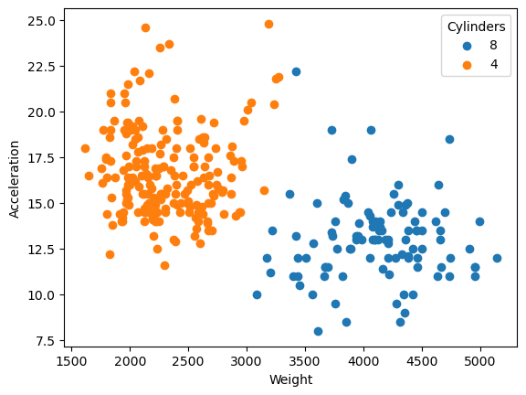

```python
# If we call plt.scatter() twice to display two plots
# To display all plots simultaneously we include plt.show() at the very end.
# The idea is that the graphs are stacked on top of each other

df_8 = carfeatures.query("cylinders == 8")
df_4 = carfeatures.query("cylinders == 4")

plt.scatter(x = df_8["weight"],y = df_8["acceleration"])
plt.scatter(x = df_4["weight"],y = df_4["acceleration"])
plt.legend(labels = ["8","4"],
           title  = "Cylinders")

plt.xlabel("Weight")
plt.ylabel("Acceleration")
plt.show()

# Note: If we put plt.show() in between the plots, then the results will
# be shown on separate graphs instead.
```

Compute plots by all categories

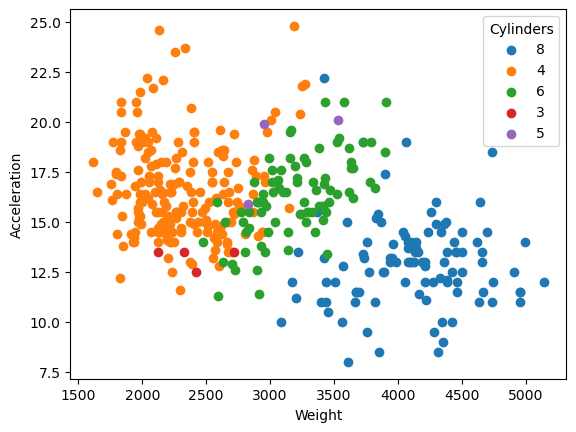

```python
# Compute number of unique categories
list_unique_cylinders = pd.unique(carfeatures["cylinders"])

# Use a for loop to plot a scatter plot between "weight" and "acceleration"
# for each category. Each plot  will have a different color

for category in list_unique_cylinders:
    df   = carfeatures.query("cylinders == @category")
    plt.scatter(x = df["weight"], y = df["acceleration"])

# Add labels and a legends
plt.xlabel("Weight")
plt.ylabel("Acceleration")
plt.legend(labels = list_unique_cylinders,
           title  = "Cylinders")
plt.show()
```

**Exercise:** Compute a histogram of "mpg" by cylinder count for cars with 4, 6, and 8 cylinders.Here is what it might look like (using a fake dataset):

[figure not shown]

You can make the histograms transparent by adjusting `alpha` in

```
    plt.hist(x = ..., alpha = 0.5)
```

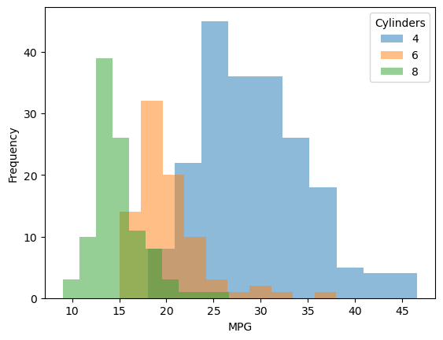

```python
# your code here

plot_cylinders = [4, 6, 8]

for num_cylinders in plot_cylinders:
    df   = carfeatures.query("cylinders == @num_cylinders")
    plt.hist(x = df["mpg"], alpha = 0.5)

# Add labels and a legends
plt.xlabel("MPG")
plt.ylabel("Frequency")
plt.legend(labels = plot_cylinders,
           title  = "Cylinders")
plt.show()
```